# Assignment 02

Author

Carissa Feliciano

# Data Wrangling

```r
library(data.table)
library(dplyr)
```

```r
# Download the individual CHS dataset
if (!file.exists("chs_indiv.csv"))
  download.file(
    url = "raw.githubusercontent.com/USCbiostats/data-science-data/master/01_chs/chs_individual.csv",
    destfile = "chs_indiv.csv",
    method   = "libcurl",
    timeout  = 60
    )

chs_indiv <- data.table::fread("chs_indiv.csv")
chs_indiv <- as.data.frame(chs_indiv)
```

```r
# Download the regional CHS dataset
if (!file.exists("chs_regional.csv"))
  download.file(
    url = "https://raw.githubusercontent.com/USCbiostats/data-science-data/master/01_chs/chs_regional.csv",
    destfile = "chs_regional.csv",
    method   = "libcurl",
    timeout  = 60
    )

chs_region <- data.table::fread("chs_regional.csv")
chs_region <- as.data.frame(chs_region)
```

```r
# Merge datasets
chs <- merge(
  x = chs_indiv,
  y = chs_region,
  by = "townname",
  all.x = TRUE,
  all.y = FALSE
)
```

## 1. Check for duplicates, impute missing values

```r
# Count the number of rows
nrow(chs_indiv)
```

```
[1] 1200
```

```r
nrow(chs_region)
```

```
[1] 12
```

```r
nrow(chs)
```

```
[1] 1200
```

The number of rows in the individual CHS dataset (chs_indiv) matches the number of rows in the merged dataset.

```r
# Determine which columns have missing values
sapply(chs, function(x) sum(is.na(x)))
```

```
     townname           sid          male          race      hispanic
            0             0             0             0             0
       agepft        height        weight           bmi        asthma
           89            89            89            89            31
active_asthma father_asthma mother_asthma        wheeze      hayfever
            0           106            56            71           118
      allergy   educ_parent         smoke          pets      gasstove
           63            64            40             0            33
          fev           fvc          mmef     pm25_mass      pm25_so4
           95            97           106             0             0
     pm25_no3      pm25_nh4       pm25_oc       pm25_ec       pm25_om
            0             0             0             0             0
      pm10_oc       pm10_ec       pm10_tc        formic        acetic
            0             0             0             0             0
          hcl          hno3        o3_max         o3106         o3_24
            0             0             0             0             0
          no2          pm10       no_24hr      pm2_5_fr         iacid
            0             0           100           300             0
        oacid   total_acids           lon           lat
            0             0             0             0
```

```r
# Impute missing numerical data using the average amongst individuals with the same values for the “male” and “hispanic” variables.
chs <- chs |>
  group_by(male, hispanic) |>
  mutate(
    agepft = coalesce(agepft, mean(agepft, na.rm = TRUE)),
    height = coalesce(height, mean(height, na.rm = TRUE)),
    weight = coalesce(weight, mean(weight, na.rm = TRUE)),
    bmi = coalesce(bmi, mean(bmi, na.rm = TRUE)),
    fev = coalesce(fev, mean(fev, na.rm = TRUE)),
    fvc = coalesce(fvc, mean(fvc, na.rm = TRUE)),
    mmef = coalesce(mmef, mean(mmef, na.rm = TRUE)),
  ) |>
  ungroup()
```

```r
library(DescTools)
# Impute missing categorical variable using the mode.
chs <- chs |>
  group_by(male, hispanic) |>
  mutate(
    asthma = coalesce(asthma, Mode(asthma, na.rm = TRUE)),
    father_asthma = coalesce(father_asthma, Mode(father_asthma, na.rm = TRUE)),
    mother_asthma = coalesce(mother_asthma, Mode(mother_asthma, na.rm = TRUE)),
    wheeze = coalesce(wheeze, Mode(wheeze, na.rm = TRUE)),
    hayfever = coalesce(hayfever, Mode(hayfever, na.rm = TRUE)),
    allergy = coalesce(allergy, Mode(allergy, na.rm = TRUE)),
    educ_parent = coalesce(educ_parent, Mode(educ_parent, na.rm = TRUE)),
    smoke = coalesce(smoke, Mode(smoke, na.rm = TRUE)),
    gasstove = coalesce(gasstove, Mode(gasstove, na.rm = TRUE)),
  ) |>
  ungroup()
```

## 2. Create a new categorical variable named “obesity_level” and create a summary table.

```r
# Create a new categorical variable named "obesity_level" using the BMI measurement (underweight BMI<14; normal BMI 14-22; overweight BMI 22-24; obese BMI>24).
chs <- chs |>
  mutate(
    obesity_level = case_when(
      bmi < 14 ~ "underweight",
      bmi >= 14 & bmi <= 22 ~ "normal",
      bmi > 22 & bmi <= 24 ~ "overweight",
      bmi > 24 ~ "obese"
    )
  )
```

```r
library(knitr)

# Create a summary table
obesity_sum <- chs |>
  group_by(obesity_level) |>
  summarize(
    min_bmi = min(bmi, na.rm = TRUE),
    max_bmi = max(bmi, na.rm = TRUE),
    total_obs = n()
    ) |>
  arrange(factor(obesity_level, levels = c("underweight", "normal", "overweight", "obese")))

kable(obesity_sum, digits = 3)
```

| obesity_level | min_bmi | max_bmi | total_obs |
| --- | --- | --- | --- |
| underweight | 11.296 | 13.986 | 35 |
| normal | 14.004 | 21.964 | 975 |
| overweight | 22.024 | 23.996 | 87 |
| obese | 24.006 | 41.266 | 103 |

## 3. Create a new categorical variable named “smoke_gas_exposure” that summarizes “Second Hand Smoke” and “Gas Stove” with four categories.

```r
chs <- chs |>
  mutate(
    smoke_gas_exposure = case_when(
      smoke == 0 & gasstove == 0 ~ "none",
      smoke == 1 & gasstove == 0 ~ "smoke",
      smoke == 0 & gasstove == 1 ~ "gas",
      smoke == 1 & gasstove == 1 ~ "both"
    )
  )
```

## 4. Create four summary tables showing the average and sd of “Forced expiratory volume in 1 second (ml)” by town, sex, obesity level, and “smoke_gas_exposure”

```r
# FEV1 by town
fev_town <- chs |>
  group_by(townname) |>
  summarize(
    avg_fev = mean(fev, na.rm = TRUE),
    sd_fev = sd(fev, na.rm = TRUE)
  )

kable(fev_town)
```

| townname | avg_fev | sd_fev |
| --- | --- | --- |
| Alpine | 2087.101 | 291.1768 |
| Atascadero | 2075.897 | 324.0935 |
| Lake Elsinore | 2038.849 | 303.6956 |
| Lake Gregory | 2084.700 | 319.9593 |
| Lancaster | 2003.044 | 317.1298 |
| Lompoc | 2034.354 | 351.0454 |
| Long Beach | 1985.861 | 319.4625 |
| Mira Loma | 1985.202 | 324.9634 |
| Riverside | 1989.881 | 277.5065 |
| San Dimas | 2026.794 | 318.7845 |
| Santa Maria | 2025.750 | 312.1725 |
| Upland | 2024.266 | 343.1637 |

```r
#FEV1 by sex
fev_sex <- chs |>
  rename(sex = male) |>
  mutate(sex = if_else(sex ==1, "Male", "Female")) |>
  group_by(sex) |>
  summarize(
    avg_fev = mean(fev, na.rm = TRUE),
    sd_fev = sd(fev, na.rm = TRUE)
  )

kable(fev_sex)
```

| sex | avg_fev | sd_fev |
| --- | --- | --- |
| Female | 1958.911 | 311.9181 |
| Male | 2103.787 | 307.5123 |

```r
#FEV1 by obesity level
fev_obesity <- chs |>
  group_by(obesity_level) |>
  summarize(
    avg_fev = mean(fev, na.rm = TRUE),
    sd_fev = sd(fev, na.rm = TRUE)
  ) |>
  arrange(factor(obesity_level, levels = c("underweight", "normal", "overweight", "obese")))

kable(fev_obesity)
```

| obesity_level | avg_fev | sd_fev |
| --- | --- | --- |
| underweight | 1698.327 | 303.3983 |
| normal | 1999.794 | 295.1964 |
| overweight | 2224.322 | 317.4261 |
| obese | 2266.154 | 325.4710 |

```r
#FEV1 by smoke_gas_exposure
fev_smoke <- chs |>
  group_by(smoke_gas_exposure) |>
  summarize(
    avg_fev = mean(fev, na.rm = TRUE),
    sd_fev = sd(fev, na.rm = TRUE)
  ) |>
  arrange(factor(smoke_gas_exposure, levels = c("none", "smoke", "gas", "both")))

kable(fev_smoke)
```

| smoke_gas_exposure | avg_fev | sd_fev |
| --- | --- | --- |
| none | 2056.693 | 328.7843 |
| smoke | 2055.714 | 295.6475 |
| gas | 2022.671 | 319.3449 |
| both | 2024.778 | 300.6313 |

# Looking at the data (EDA)

## Check the size of the data

```r
dim(chs)
```

```
[1] 1200   51
```

There are 1200 rows and 51 columns.

## Look at the top and bottom

```r
head(chs)
```

```
# A tibble: 6 × 51
  townname   sid  male race  hispanic agepft height weight   bmi asthma
  <chr>    <int> <int> <chr>    <int>  <dbl>  <dbl>  <dbl> <dbl>  <int>
1 Alpine     841     1 W            1  10.5     150     78  15.8      0
2 Alpine     835     0 W            0  10.1     143     69  15.3      0
3 Alpine     838     0 O            1   9.49    133     62  15.9      0
4 Alpine     840     0 W            0   9.97    146     78  16.6      0
5 Alpine     865     0 W            0  10.0     162    140  24.2      1
6 Alpine     867     0 W            1   9.96    141     94  21.5      0
# ℹ 41 more variables: active_asthma <int>, father_asthma <int>,
#   mother_asthma <int>, wheeze <int>, hayfever <int>, allergy <int>,
#   educ_parent <int>, smoke <int>, pets <int>, gasstove <int>, fev <dbl>,
#   fvc <dbl>, mmef <dbl>, pm25_mass <dbl>, pm25_so4 <dbl>, pm25_no3 <dbl>,
#   pm25_nh4 <dbl>, pm25_oc <dbl>, pm25_ec <dbl>, pm25_om <dbl>, pm10_oc <dbl>,
#   pm10_ec <dbl>, pm10_tc <dbl>, formic <dbl>, acetic <dbl>, hcl <dbl>,
#   hno3 <dbl>, o3_max <dbl>, o3106 <dbl>, o3_24 <dbl>, no2 <dbl>, …
```

```r
tail(chs)
```

```
# A tibble: 6 × 51
  townname   sid  male race  hispanic agepft height weight   bmi asthma
  <chr>    <int> <int> <chr>    <int>  <dbl>  <dbl>  <dbl> <dbl>  <int>
1 Upland    1866     0 O            1   9.81   139    60    14.1      0
2 Upland    1867     0 M            1   9.62   140    71    16.5      0
3 Upland    2033     0 M            0  10.1    130    67    18.0      0
4 Upland    2031     1 W            0   9.80   135    83    20.7      0
5 Upland    2032     1 W            0   9.55   137    59    14.3      0
6 Upland    2053     0 W            0   9.85   139.   77.4  18.1      0
# ℹ 41 more variables: active_asthma <int>, father_asthma <int>,
#   mother_asthma <int>, wheeze <int>, hayfever <int>, allergy <int>,
#   educ_parent <int>, smoke <int>, pets <int>, gasstove <int>, fev <dbl>,
#   fvc <dbl>, mmef <dbl>, pm25_mass <dbl>, pm25_so4 <dbl>, pm25_no3 <dbl>,
#   pm25_nh4 <dbl>, pm25_oc <dbl>, pm25_ec <dbl>, pm25_om <dbl>, pm10_oc <dbl>,
#   pm10_ec <dbl>, pm10_tc <dbl>, formic <dbl>, acetic <dbl>, hcl <dbl>,
#   hno3 <dbl>, o3_max <dbl>, o3106 <dbl>, o3_24 <dbl>, no2 <dbl>, …
```

Looking at the top and bottom of the data, there do not appear to be any irregularities.

## Check the variables, check your expectations, and validate against an external source

```r
# Check the variables
str(chs)
```

```
tibble [1,200 × 51] (S3: tbl_df/tbl/data.frame)
 $ townname          : chr [1:1200] "Alpine" "Alpine" "Alpine" "Alpine" ...
 $ sid               : int [1:1200] 841 835 838 840 865 867 842 839 844 847 ...
 $ male              : int [1:1200] 1 0 0 0 0 0 1 0 1 1 ...
 $ race              : chr [1:1200] "W" "W" "O" "W" ...
 $ hispanic          : int [1:1200] 1 0 1 0 0 1 1 1 1 0 ...
 $ agepft            : num [1:1200] 10.55 10.1 9.49 9.97 10.04 ...
 $ height            : num [1:1200] 150 143 133 146 162 141 139 142 143 137 ...
 $ weight            : num [1:1200] 78 69 62 78 140 94 65 86 65 69 ...
 $ bmi               : num [1:1200] 15.8 15.3 15.9 16.6 24.2 ...
 $ asthma            : int [1:1200] 0 0 0 0 1 0 0 0 0 0 ...
 $ active_asthma     : int [1:1200] 0 0 0 0 1 0 0 0 0 0 ...
 $ father_asthma     : int [1:1200] 0 0 0 0 0 0 0 0 0 0 ...
 $ mother_asthma     : int [1:1200] 0 0 0 0 0 0 0 1 0 0 ...
 $ wheeze            : int [1:1200] 0 0 0 0 1 0 1 1 0 0 ...
```

[output cut: 37 more lines]

There are 51 variables and 1200 observations.

Check the main variables of interest (BMI, FEV, smoke_gas_exposure, obesity_level, PM2.5 mass).

```r
# BMI
summary(chs$bmi)
```

```
   Min. 1st Qu.  Median    Mean 3rd Qu.    Max.
  11.30   15.96   17.81   18.50   19.99   41.27
```

```r
sum(chs$bmi == "")
```

```
[1] 0
```

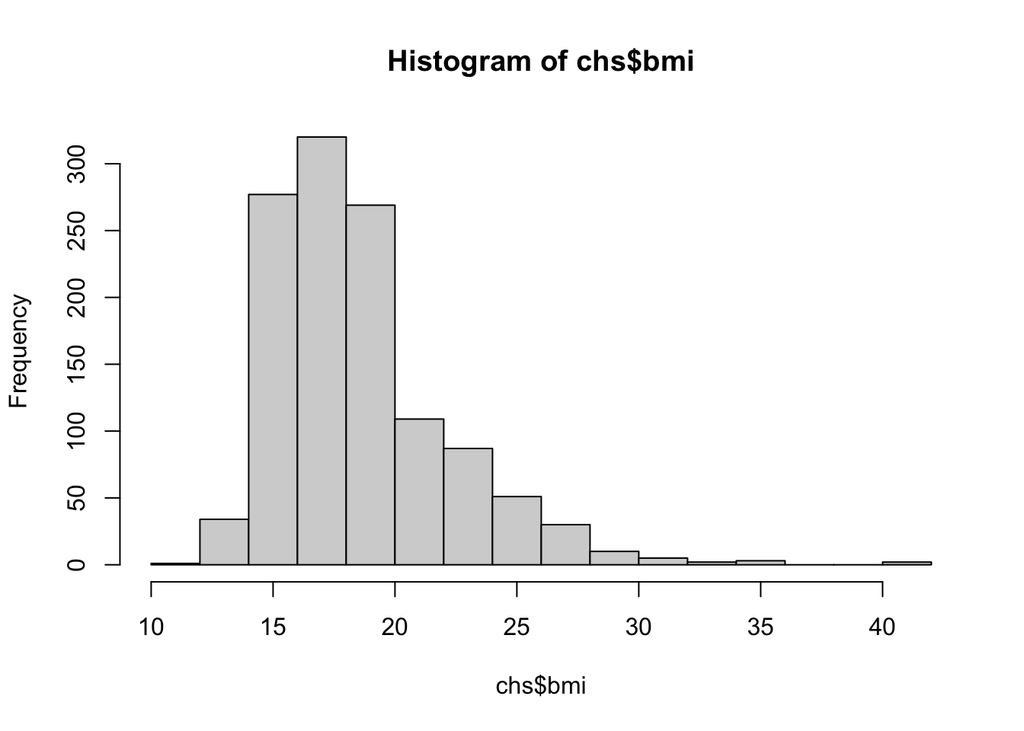

```r
hist(chs$bmi)
```

The minimum BMI, 11.3, seems very low. However, this value is possible, and it is not very different from the second lowest value of 12.1. This value is likely real. The maximum BMI of 41.27 is plausible. All NA values were imputed, and there are no observations labeled as ““.

```r
# FEV
summary(chs$fev)
```

```
   Min. 1st Qu.  Median    Mean 3rd Qu.    Max.
  984.8  1827.6  2016.4  2030.1  2223.6  3323.7
```

```r
sum(chs$fev == "")
```

```
[1] 0
```

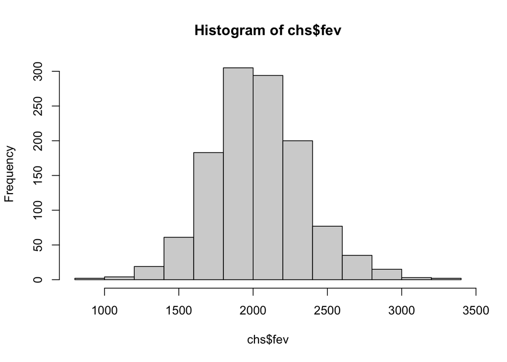

```r
hist(chs$fev)
```

The range of FEV1 values (984.8-3323.7 mLs). The children in the USC Children’s Health Study were 0-17 years of age. Based on a study by Stanojevic et al., this range is plausible. All NA’s were imputed, and there are no observations labeled ““.

Stanojevic S et al. Reference ranges for spirometry across all ages: a new approach. American journal of respiratory and critical care medicine. 2008 Feb 1;177(3):253-60.

```r
# Smoke_gas_exposure
table(chs$smoke_gas_exposure)
```

```
 both   gas  none smoke
  154   791   219    36
```

The observations sum to 1200.

```r
#Obesity_level
table(chs$obesity_level)
```

```
     normal       obese  overweight underweight
        975         103          87          35
```

The observations sum to 1200.

```r
# PM2.5 mass
summary(chs$pm25_mass)
```

```
   Min. 1st Qu.  Median    Mean 3rd Qu.    Max.
  5.960   7.615  10.545  14.362  20.988  29.970
```

```r
sum(chs$pm25_mass == "")
```

```
[1] 0
```

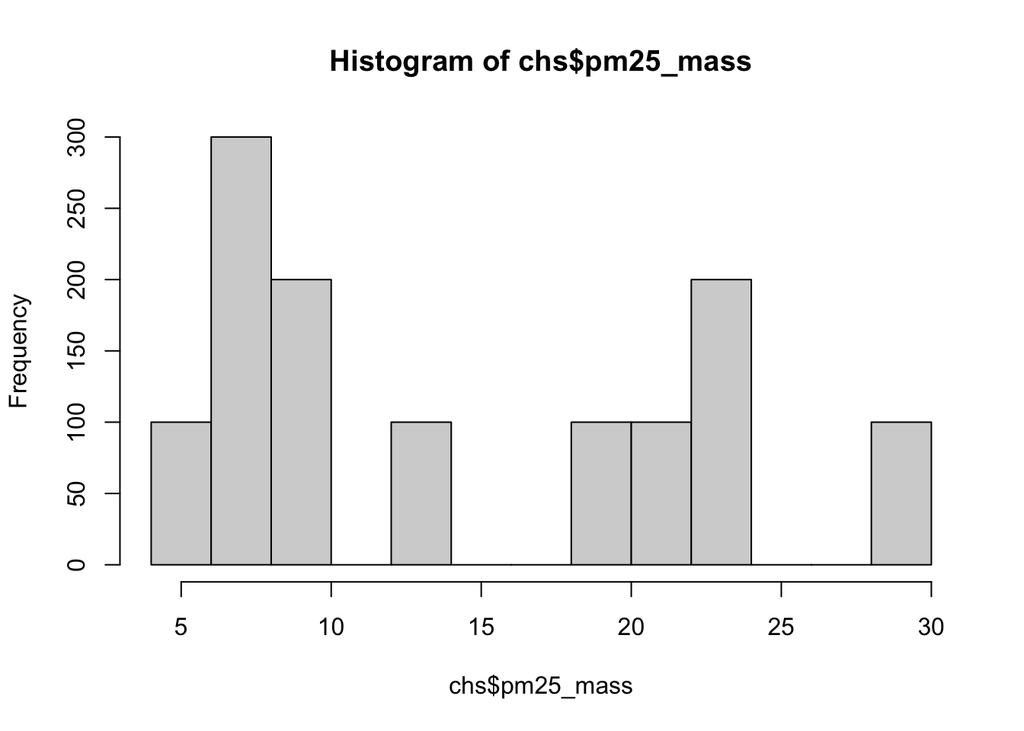

```r
hist(chs$pm25_mass)
```

The range of PM2.5 mass concentrations is 5.96 to 29.97, which is plausible. There are no observations labeled as NA or ““.

# Visualization

## 1. Facet plot showing scatterplots with regression lines of BMI vs FEV by “townname”.

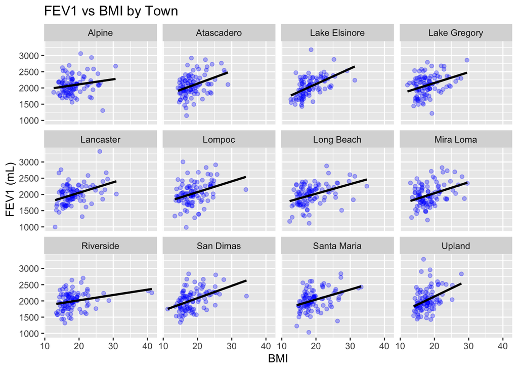

```r
library(ggplot2)
ggplot(data = chs, mapping = aes(x = bmi, y = fev)) +
  geom_point(col = "blue", alpha = 0.3) +
  geom_smooth(method = lm, se = FALSE, col = "black") +
  labs(x = "BMI", y = "FEV1 (mL)", title = "FEV1 vs BMI by Town") +
  facet_wrap(~ townname, nrow = 3)
```

Generally, as BMI increases, FEV1 increases. The slope is the steepest for Upland, Lake Elsinore, and San Dimas.

## 2. Stacked histograms of FEV by BMI category and FEV by smoke/gas exposure using a custom color scheme.

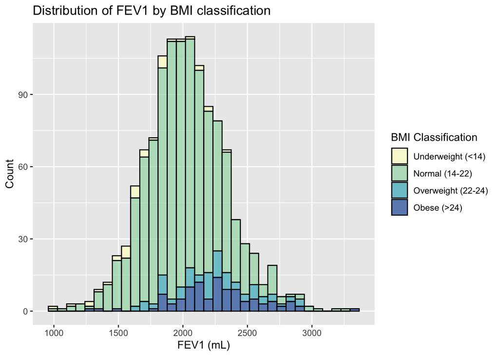

```r
library(RColorBrewer)

# Arranging levels for obesity_level
chs <- chs |>
  mutate(obesity_level = factor(obesity_level, levels = c("underweight", "normal", "overweight", "obese")))

# Stacked histogram of FEV by BMI category
ggplot(data = chs, mapping = aes(x = fev, fill = obesity_level)) +
  geom_histogram(position = "stack", bins = 34, color = "black", alpha = 0.7) +
  scale_fill_brewer(
    palette = "YlGnBu",
    name = "BMI Classification",
    labels = c(
      "underweight" = "Underweight (<14)",
      "normal" = "Normal (14-22)",
      "overweight" = "Overweight (22-24)",
      "obese" = "Obese (>24)"
      )
    ) +
  labs(x = "FEV1 (mL)", y = "Count", title = "Distribution of FEV1 by BMI classification")
```

Including all individuals, the distribution of FEV1 is approximately normal with a peak at approximately 2000 mL. Individuals who are overweight or obese tend to have FEV1 values around 1750 mLs or greater, with a peak around 2250 mL. The lower FEV1 values are primarily from individuals who are underweight or normal weight.

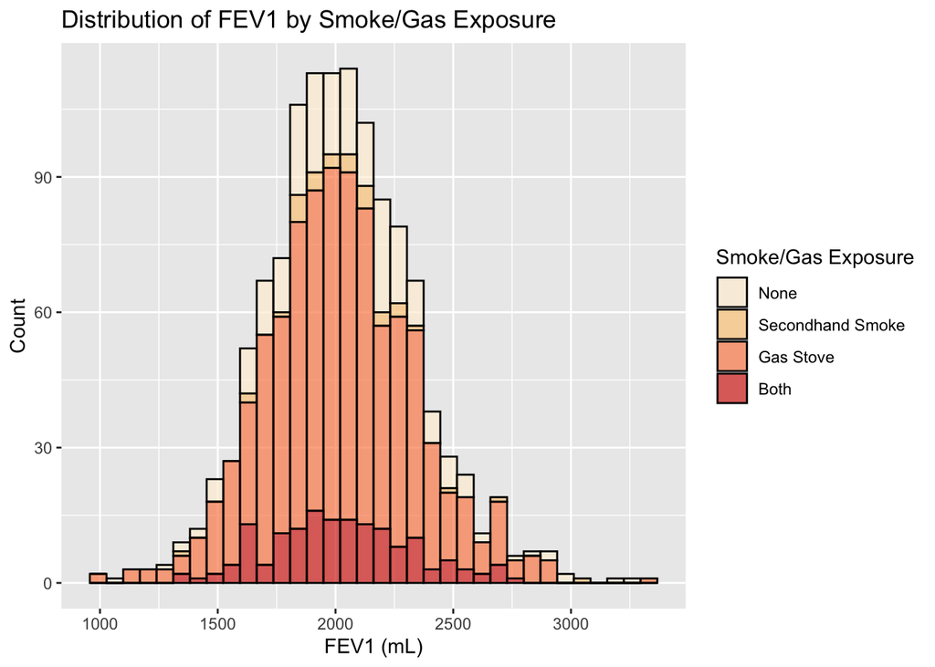

```r
# Arranging levels for smoke_gas_exposure
chs <- chs |>
  mutate(smoke_gas_exposure = factor(smoke_gas_exposure, levels = c("none", "smoke", "gas", "both")))

# Stacked histogram of FEV by smoke/gas exposure using a custom color scheme.
ggplot(data = chs, mapping = aes(x = fev, fill = smoke_gas_exposure)) +
  geom_histogram(position = "stack", bins = 34, color = "black", alpha = 0.7) +
  scale_fill_brewer(
    palette = "OrRd",
    name = "Smoke/Gas Exposure",
    labels = c(
      "none" = "None",
      "smoke" = "Secondhand Smoke",
      "gas" = "Gas Stove",
      "both" = "Both"
      )
    ) +
  labs(x = "FEV1 (mL)", y = "Count", title = "Distribution of FEV1 by Smoke/Gas Exposure")
```

Including all individuals, the distribution of FEV1 is approximately normal with a peak at approximately 2000 mL. The majority of individuals were exposed to gas stoves only. It appears the distribution of FEV1 values is consistent among the different exposure groups, with the majority of FEV1 values clustering around 2000 mL.

## Barchart of BMI by smoke/gas exposure

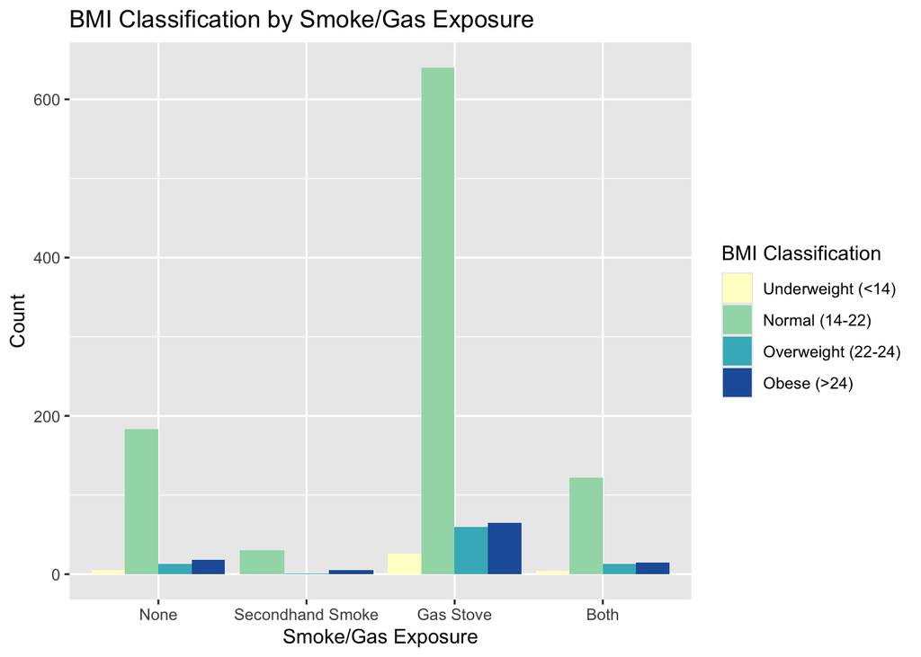

```r
ggplot(data = chs) +
  geom_bar(mapping = aes(x = smoke_gas_exposure, fill = obesity_level), position = "dodge") +
  labs(x = "Smoke/Gas Exposure", y = "Count", title = "BMI Classification by Smoke/Gas Exposure") +
  scale_fill_brewer(
    palette = "YlGnBu",
    name = "BMI Classification",
    labels = c(
      "underweight" = "Underweight (<14)",
      "normal" = "Normal (14-22)",
      "overweight" = "Overweight (22-24)",
      "obese" = "Obese (>24)"
      )
    ) +
  scale_x_discrete(
    labels = c(
      "none" = "None",
      "smoke" = "Secondhand Smoke",
      "gas" = "Gas Stove",
      "both" = "Both"
      ),
  )
```

There is a similar distribution of BMI across all exposure groups. The highest proportion of individuals are classified as normal weight, followed by obese, overweight, and then underweight. The proportion of individuals classified as normal weight is significantly higher than other BMI categories. There are no individuals classified as underweight in the secondhand smoke exposure group, likely due to the overall small number of individuals with only secondhand smoke exposure. Among all individuals, the majority have only gas stove exposure.

## 4. Statistical summary graphs of FEV by BMI and FEV by smoke/gas exposure category.

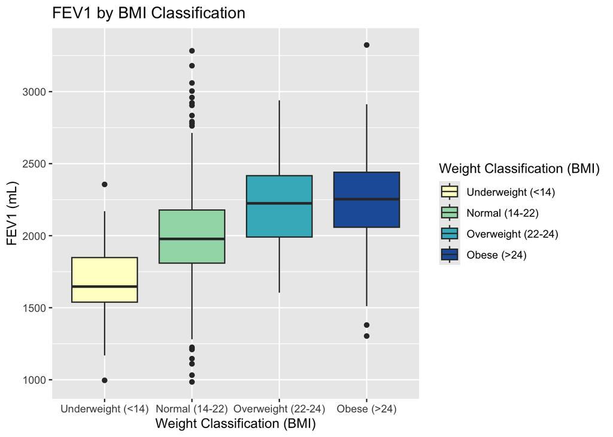

```r
#Statistical summary graph of FEV by BMI
ggplot(data = chs) +
  geom_boxplot(mapping = aes(x = obesity_level, y = fev, fill = obesity_level)) +
  scale_fill_brewer(
    palette = "YlGnBu",
    name = "Weight Classification (BMI)",
    labels = c(
      "underweight" = "Underweight (<14)",
      "normal" = "Normal (14-22)",
      "overweight" = "Overweight (22-24)",
      "obese" = "Obese (>24)"
      )
    ) +
  scale_x_discrete(
    labels = c(
      "underweight" = "Underweight (<14)",
      "normal" = "Normal (14-22)",
      "overweight" = "Overweight (22-24)",
      "obese" = "Obese (>24)"
      )
    ) +
  labs(x = "Weight Classification (BMI)", y = "FEV1 (mL)", title = "FEV1 by BMI Classification")
```

As the weight classification increases from underweight to overweight, the median FEV1 increases. The median FEV1s are very similar for the overweight and obese group. For the underweight group, the distribution of FEV1 is positively skewed. For the overweight group, the distribution of FEV1 is slightly negatively skewed. The distributions of FEV1 are approximately normal for the normal weight and obese groups. The median FEV1 is approximately 1625 mL for the underweight group, 2000 mL for the normal weight group, 2225 mL for the overweight group, and 2250 mL for the obese group. The normal weight group has the greatest amount of outliers.

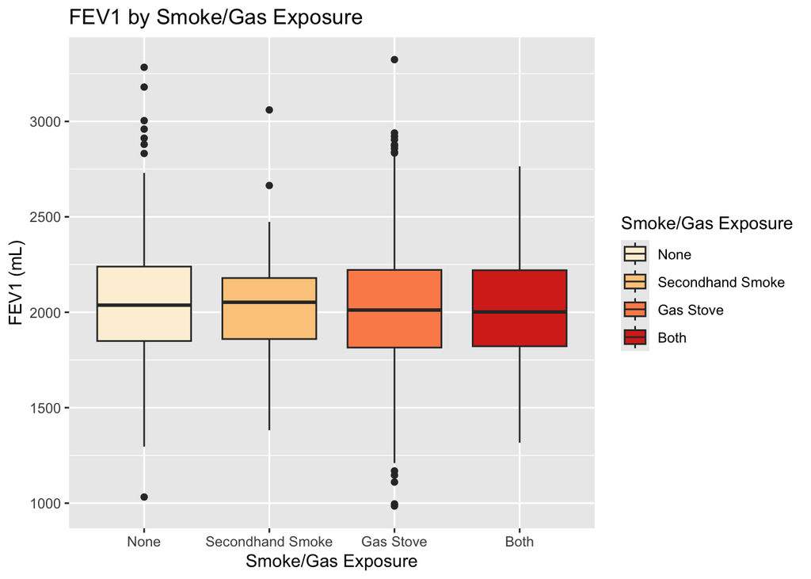

```r
#Statistical summary graph of FEV by Smoke/Gas Exposure
ggplot(data = chs) +
  geom_boxplot(mapping = aes(x = smoke_gas_exposure, y = fev, fill = smoke_gas_exposure)) +
  scale_fill_brewer(
    palette = "OrRd",
    name = "Smoke/Gas Exposure",
    labels = c(
      "none" = "None",
      "smoke" = "Secondhand Smoke",
      "gas" = "Gas Stove",
      "both" = "Both"
      )
    ) +
  scale_x_discrete(
    labels = c(
      "none" = "None",
      "smoke" = "Secondhand Smoke",
      "gas" = "Gas Stove",
      "both" = "Both"
      )
  ) +
  labs(x = "Smoke/Gas Exposure", y = "FEV1 (mL)", title = "FEV1 by Smoke/Gas Exposure")
```

Overall, it appears that smoke/gas exposure does not have a significant effect on FEV1. The median FEV1s are approximately the same for the no exposure, gas stove exposure, and both exposures groups (2000 mL). The median FEV1 for the secondhand smoke group (2050 mL) is very slightly higher. The range is the smallest for the secondhand smoke group (1375-2500 mL). The range for the other three groups is approximately 1250-2750 mL. The distributions are approximately normal of the no exposure and gas stove exposure groups. The distribution for the secondhand group is negatively skewed. The distribution for the both exposures group is slightly positively skewed.

## 5. Leaflet map showing the concentrations of PM2.5 mass in each of the CHS communities.

```r
library(leaflet)

pm25.pal <- colorNumeric(c('royalblue', 'gold', 'red3'), domain = chs$pm25_mass)

leaflet(chs) |>
  addTiles() |>
  addCircles(
    lat = ~lat,
    lng = ~lon,
    label = ~paste0(round(pm25_mass,2), ' ug/m^3'), color = ~ pm25.pal(pm25_mass),
    opacity = 1, fillOpacity = 1, radius = 500
  ) |>
  addLegend('bottomleft', pal = pm25.pal, values = chs$pm25_mass,
            title = 'PM2.5 Mass (ug/m^3)', opacity = 1)
```

[interactive chart not shown]

The PM2.5 mass concentrations were highest in the CHS communities in Riverside County and East LA County. A CHS community near Eastvale had the highest PM2.5 mass concentration of 29.97 ug/m^3. The PM2.5 mass concentrations were the lowest in the coastal areas north of Santa Barbara. All of the CHS communities were located in Southern California.

## 6. Choose a visualization to examine whether PM2.5 mass is associated with FEV.

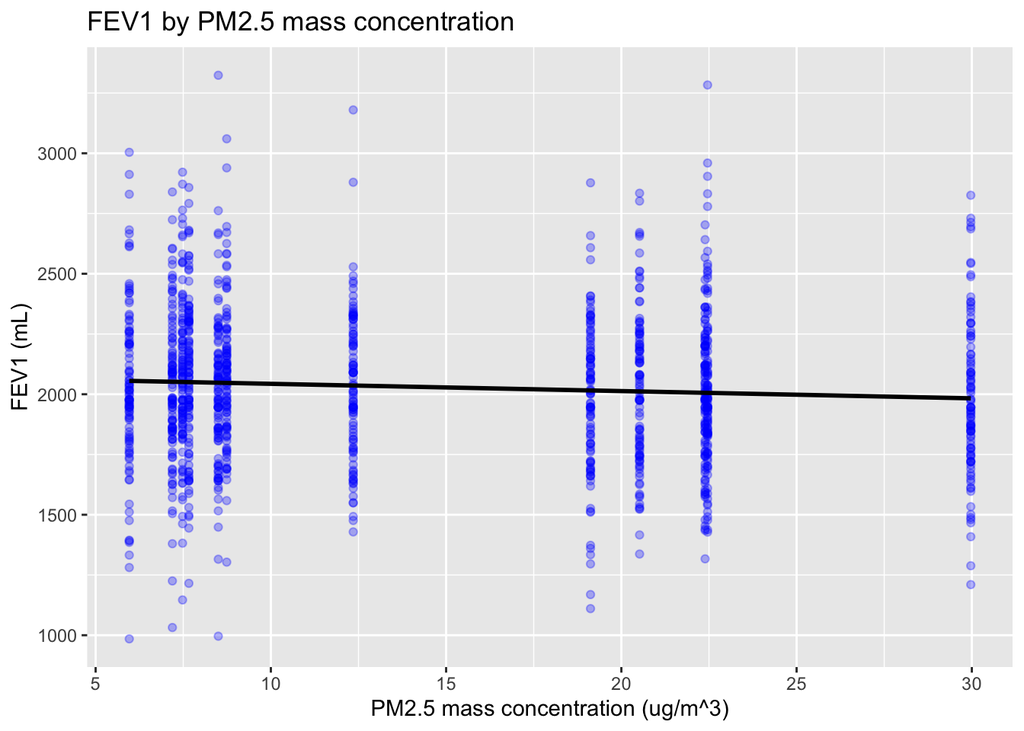

```r
ggplot(data = chs, mapping = aes(x = pm25_mass, y = fev)) +
  geom_point(alpha = 0.3, col = "blue") +
  geom_smooth(method = lm, se = FALSE, col = "black") +
  labs(x = "PM2.5 mass concentration (ug/m^3)", y = "FEV1 (mL)", title = "FEV1 by PM2.5 mass concentration")
```

Overall, it appears that PM2.5 mass concentration is not associated with FEV1. The slope of the regression line is very slightly down-trending but close to 0. FEV1 is randomly distributed about 2000 mL for each PM2.5 mass concentration.